# Mediation Analysis

Yan Zhu

2023-10-14

# Set up

Read the data, and explore the data set.

```r
d <- read_csv("/Users/yan/Desktop/sample_code/Design and Analysis of Psychological Experiments/Data/Outgroup.csv", show_col_types = FALSE)
head(d)
```

```
## # A tibble: 6 × 6
##   subID condition heterog individ subgr  like
##   <dbl>     <dbl>   <dbl>   <dbl> <dbl> <dbl>
## 1     1         1       9      19     7     5
## 2     2         1       4       4     4     7
## 3     3         1       6      14     6     6
## 4     4         1       5      12     4     5
## 5     5         1       8      12     5     8
## 6     6         1       5       6     4     4
```

```r
describe(d)
```

```
##           vars  n  mean   sd median trimmed  mad min max range  skew kurtosis
## subID        1 20 10.50 5.92   10.5   10.50 7.41   1  20    19  0.00    -1.38
## condition    2 20  1.50 0.51    1.5    1.50 0.74   1   2     1  0.00    -2.10
## heterog      3 20  4.90 2.25    5.0    4.88 1.48   1   9     8  0.09    -0.61
## individ      4 20  9.65 4.64    8.0    9.31 5.93   4  19    15  0.46    -1.15
## subgr        5 20  4.15 1.73    4.0    4.19 1.48   1   7     6 -0.10    -0.79
## like         6 20  4.45 1.76    4.5    4.50 1.48   1   8     7 -0.17    -0.32
##             se
## subID     1.32
## condition 0.11
## heterog   0.50
## individ   1.04
## subgr     0.39
## like      0.39
```

# Exploring Data

Create a correlation matrix with density plots and scatter plots.

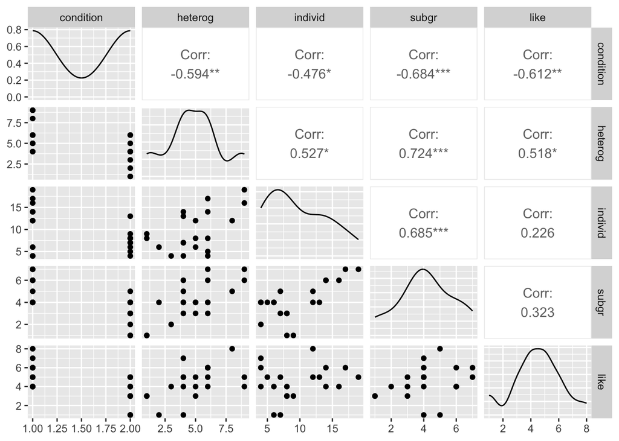

```r
d %>%
  select(-subID) %>%
  GGally::ggpairs()
```

Center the condition variable (around 0).

```r
d$condition_c <- dplyr::recode(d$condition, "1" = -.5, "2" = .5)
```

Run a model to test whether participants who rated their ingroup had higher heterog scores than participants who rated their outgroup. What is the name of this particular statistical test?

```r
mod_1 <- lm(heterog ~ condition_c, data = d)
(mod_1_sum <- summary(mod_1))
```

```
##
## Call:
## lm(formula = heterog ~ condition_c, data = d)
##
## Residuals:
##    Min     1Q Median     3Q    Max
##   -2.6   -1.3   -0.2    1.5    2.8
##
## Coefficients:
##             Estimate Std. Error t value Pr(>|t|)
## (Intercept)    4.900      0.415  11.807 6.55e-10 ***
## condition_c   -2.600      0.830  -3.133  0.00575 **
## ---
## Signif. codes:  0 '***' 0.001 '**' 0.01 '*' 0.05 '.' 0.1 ' ' 1
##
## Residual standard error: 1.856 on 18 degrees of freedom
## Multiple R-squared:  0.3528, Adjusted R-squared:  0.3169
## F-statistic: 9.813 on 1 and 18 DF,  p-value: 0.005754
```

```r
mod_1_sum$coefficients[, 't value']^2
```

```
## (Intercept) condition_c
##  139.412903    9.812903
```

*This is an independent (or two-samples) t-test.*

**Summary:** Participants that were assigned to rate the outgroup reported heterogeneity scores 2.60 units lower than participants who rated the ingroup, F(1,18)=9.81,p=.006.

**The intercept of this model represent:** For participants theoretically in-between the two experimental conditions, the expected heterogeneity score is 4.90. Because there are equal Ns per condition, this is also the average heterogeneity score for the sample.